# Identifying opportunities in Jumpman23 delivery activity in the NYC market

##### an analysis by Alex Talbott

Our goal in this analysis is to:

1. **Provide a market analysis of Jumpman23 activity in New York City for the given time period.**
2. **Provide insight into potential data integrity issues.**
3. **Visualize the NYC market using maps.**

```python
# read in libraries
import numpy as np
import pandas as pd
from plotnine import *
import folium
from folium import plugins
import datetime as dt
import warnings
warnings.filterwarnings('ignore')

pd.set_option('display.max_colwidth',1000)
pd.set_option('display.max_rows', 500)


jump23 = pd.read_csv('C:\\Users\\alex.talbott\\Desktop\\Alex Talbott Stuff\\Python\\Datasets\\analyze_me.csv')
```

## Initial Data Cleaning & Exploration

```python
"We have {} total deliveries for the time period.".format(jump23.shape[0])
```

```
'We have 5983 total deliveries for the time period.'
```

```python
jump23.dtypes
```

```
delivery_id                              int64
customer_id                              int64
jumpman_id                               int64
vehicle_type                            object
pickup_place                            object
place_category                          object
item_name                               object
item_quantity                          float64
item_category_name                      object
how_long_it_took_to_order               object
pickup_lat                             float64
pickup_lon                             float64
dropoff_lat                            float64
dropoff_lon                            float64
when_the_delivery_started               object
when_the_Jumpman_arrived_at_pickup      object
when_the_Jumpman_left_pickup            object
when_the_Jumpman_arrived_at_dropoff     object
dtype: object
```

**Rename columns for usability**

```python
jump23.rename({"when_the_delivery_started" : "delivery_start_time", "how_long_it_took_to_order" : "ordering_duration",
              "when_the_Jumpman_arrived_at_pickup" : "merchant_arrival_time", "when_the_Jumpman_left_pickup" : "merchant_departure_time",
              "when_the_Jumpman_arrived_at_dropoff" : "customer_arrival_time"}, axis = 1, inplace = True)
```

**Fix datatypes for time series analysis**

We need to convert strings into datetime formats.

```python
jump23.iloc[5,-4:]
```

```
delivery_start_time        2014-10-22 18:56:36.348939
merchant_arrival_time      2014-10-22 19:18:49.953427
merchant_departure_time     2014-10-22 19:27:10.57897
customer_arrival_time      2014-10-22 19:36:53.801191
Name: 5, dtype: object
```

```python
jump23[['delivery_start_time', 'merchant_arrival_time', 'merchant_departure_time', 'customer_arrival_time']] = jump23[['delivery_start_time', 'merchant_arrival_time', 'merchant_departure_time', 'customer_arrival_time']].apply(pd.to_datetime)
```

```python
jump23.dtypes
```

```
delivery_id                         int64
customer_id                         int64
jumpman_id                          int64
vehicle_type                       object
pickup_place                       object
place_category                     object
item_name                          object
item_quantity                     float64
item_category_name                 object
ordering_duration                  object
pickup_lat                        float64
pickup_lon                        float64
dropoff_lat                       float64
dropoff_lon                       float64
delivery_start_time        datetime64[ns]
merchant_arrival_time      datetime64[ns]
merchant_departure_time    datetime64[ns]
customer_arrival_time      datetime64[ns]
dtype: object
```

```python
jump23.iloc[5,-4:]
```

```
delivery_start_time        2014-10-22 18:56:36.348939
merchant_arrival_time      2014-10-22 19:18:49.953427
merchant_departure_time    2014-10-22 19:27:10.578970
customer_arrival_time      2014-10-22 19:36:53.801191
Name: 5, dtype: object
```

**Identify NaNs & Nulls**

```python
jump23.isna().sum()
```

```
delivery_id                   0
customer_id                   0
jumpman_id                    0
vehicle_type                  0
pickup_place                  0
place_category              883
item_name                  1230
item_quantity              1230
item_category_name         1230
ordering_duration          2945
pickup_lat                    0
pickup_lon                    0
dropoff_lat                   0
dropoff_lon                   0
delivery_start_time           0
merchant_arrival_time       550
merchant_departure_time     550
customer_arrival_time         0
dtype: int64
```

We know that Jumpmen occasionally order ahead of time to save time. For this analysis, we will make the assumption that this is likely causing the missing time values for arriving at and departing from merchants. A quick look through the records with missing time value confirms this as a possibility.

It makes sense that we have null merchant arrival and departure times, but does not make sense we have null item quantities, item names, item categories, and place categories. This is potentially a data issue. The missing item-related data appears to affect the same group of 1230 records (approximately 20% of the delivery data).

**Could it be that the missing item-related data is created by merchant-related issues for a particular geographic area of NYC? Let's plot the records with null item quantities to see if there is any pattern.**

```python
null_items = jump23[jump23.item_quantity.isnull()]
map_null_items = folium.Map(location=[jump23.pickup_lat.mean(),jump23.pickup_lon.mean()], tiles = 'stamentoner', zoom_start = 11.5)

for index, row in null_items.iterrows():
    lat = row['pickup_lat']
    lon = row['pickup_lon']
    folium.CircleMarker([lat, lon],
                        radius=5,
                        popup='null items',
                        fill_color="#3db7e4",
                       ).add_to(map_null_items)

map_null_items
```

[interactive chart not shown]

**It does not appear that the data quality issues are related to geolocation, so we will have to continue to investigate the source of the possible data corruption.**

We will fill the missing item_quantity values in with the rounded average item quantity per order.

```python
jump23['item_quantity'] = jump23['item_quantity'].fillna(jump23['item_quantity'].mean().round())
```

```python
jump23.isna().sum()
```

```
delivery_id                   0
customer_id                   0
jumpman_id                    0
vehicle_type                  0
pickup_place                  0
place_category              883
item_name                  1230
item_quantity                 0
item_category_name         1230
ordering_duration          2945
pickup_lat                    0
pickup_lon                    0
dropoff_lat                   0
dropoff_lon                   0
delivery_start_time           0
merchant_arrival_time       550
merchant_departure_time     550
customer_arrival_time         0
dtype: int64
```

We will leave the other values untouched but be mindful of them as we proceed with analysis, as they could disturb our aggregations.

## Begin Analysis

```python
max_min_times = "The dataset contains order data for the time period {start} to {finish}.".format(
    start = jump23.delivery_start_time.min(), finish = jump23.delivery_start_time.max()
)
print('\033[1m' + max_min_times + '\033[0m')
```

```
The dataset contains order data for the time period 2014-10-01 00:07:58.632482 to 2014-10-30 23:08:43.481900.
```

### Delivery Duration: How long does it take for our jumpmen to pickup and deliver items in the NYC area?

```python
jump23['delivery_duration'] = jump23['customer_arrival_time'] - jump23['delivery_start_time']
```

```python
jump23['delivery_duration'].dt.floor('min').describe()
```

```
count                      5983
mean     0 days 00:45:34.959050
std      0 days 00:20:13.498522
min             0 days 00:03:00
25%             0 days 00:32:00
50%             0 days 00:42:00
75%             0 days 00:55:00
max             0 days 05:40:00
Name: delivery_duration, dtype: object
```

**The average delivery time is 45 minutes.**

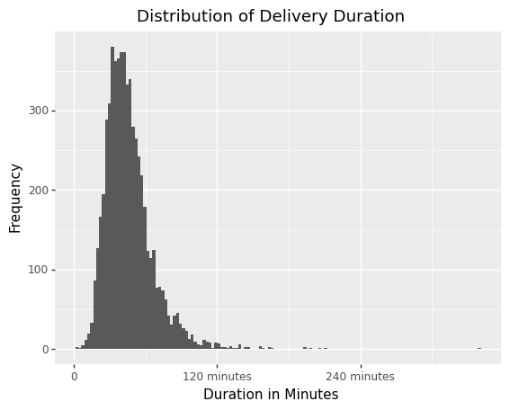

```python
(
ggplot(jump23) +
    aes('delivery_duration') +
    geom_histogram(na_rm = True) +
    labs(title = 'Distribution of Delivery Duration', x = 'Duration in Minutes', y = 'Frequency')
)
```

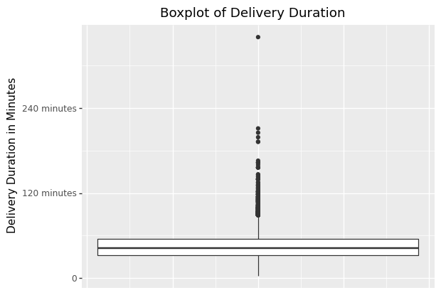

```python
(
ggplot(jump23) +
    aes(x = 0, y = 'delivery_duration') +
    geom_boxplot() +
    labs(title = 'Boxplot of Delivery Duration', x = '', y = 'Delivery Duration in Minutes') +
    theme(axis_text_x = element_blank(), axis_ticks_major_x = element_blank())

)
```

**The distribution of delivery duration is strongly skewed to the right, with some deliveries taking over three hours.**

*What do the >3 hour deliveries look like? Any noticeable patterns?*

```python
long_delivery_times = jump23.loc[jump23['delivery_duration'] > dt.timedelta(minutes = 180),:].sort_values(by = 'delivery_duration', ascending = False)
long_delivery_times
```

|  | delivery_id | customer_id | jumpman_id | vehicle_type | pickup_place | place_category | item_name | item_quantity | item_category_name | ordering_duration | pickup_lat | pickup_lon | dropoff_lat | dropoff_lon | delivery_start_time | merchant_arrival_time | merchant_departure_time | customer_arrival_time | delivery_duration |
| --- | --- | --- | --- | --- | --- | --- | --- | --- | --- | --- | --- | --- | --- | --- | --- | --- | --- | --- | --- |
| 1606 | 1381673 | 377260 | 166715 | bicycle | Blue Ribbon Fried Chicken | American | The Blue Ribbon | 1.0 | Sandwiches | NaN | 40.724340 | -73.990960 | 40.723676 | -74.010723 | 2014-10-17 17:36:36.655417 | 2014-10-17 17:39:57.071973 | 2014-10-17 22:07:54.314590 | 2014-10-17 23:16:55.184017 | 05:40:18.528600 |
| 5265 | 1449787 | 99744 | 171206 | van | Momofuku Noodle Bar | NaN | Momofuku Ramen | 1.0 | Bowls | NaN | 40.729110 | -73.984245 | 40.700326 | -73.991933 | 2014-10-25 18:35:22.318581 | NaT | NaT | 2014-10-25 22:06:46.716513 | 03:31:24.397932 |
| 3983 | 1474801 | 112380 | 118093 | scooter | Whole Foods Market | Grocery Store | Dried Cranberries | 1.0 | Nuts & Dried Fruits | NaN | 40.767890 | -73.982400 | 40.752172 | -74.004106 | 2014-10-28 17:59:44.368533 | 2014-10-28 20:21:49.776004 | 2014-10-28 21:17:09.352893 | 2014-10-28 21:25:06.127269 | 03:25:21.758736 |
| 3931 | 1348169 | 62730 | 165298 | car | Lucali | NaN | NaN | 1.0 | NaN | 00:30:14.181875 | 40.681900 | -74.000471 | 40.720116 | -73.999297 | 2014-10-12 17:43:40.338806 | NaT | NaT | 2014-10-12 21:02:34.494184 | 03:18:54.155378 |
| 2899 | 1300873 | 363127 | 72480 | car | Prosperity Dumpling | Chinese | Chives and Pork Boiled Dumplings | 1.0 | Dumplings | NaN | 40.716001 | -73.993210 | 40.763897 | -73.987686 | 2014-10-05 14:59:33.695829 | 2014-10-05 16:05:11.958985 | 2014-10-05 16:51:34.907969 | 2014-10-05 18:12:04.400313 | 03:12:30.704484 |
| 3830 | 1300873 | 363127 | 72480 | car | Prosperity Dumpling | Chinese | Noodle with Peanut Sauce (Frozen) | 1.0 | Frozen Dumplings | NaN | 40.716001 | -73.993210 | 40.763897 | -73.987686 | 2014-10-05 14:59:33.695829 | 2014-10-05 16:05:11.958985 | 2014-10-05 16:51:34.907969 | 2014-10-05 18:12:04.400313 | 03:12:30.704484 |

```python
map_long_delivery_times_new = folium.Map(location=[jump23.pickup_lat.mean(),jump23.pickup_lon.mean()], tiles = 'stamentoner', zoom_start = 11.5)
for index, row in long_delivery_times.iterrows():
    lat1 = row['pickup_lat']
    lon1 = row['pickup_lon']
    lat2 = row['dropoff_lat']
    lon2 = row['dropoff_lon']
    coords = [[lat1,lon1],[lat2,lon2]]
    folium.PolyLine(coords,
                        weight = 5,
                        color = 'red'
                       ).add_to(map_long_delivery_times_new)
    folium.CircleMarker([lat1, lon1],
                        radius=5,
                        popup='starting point',
                        fill_color="#3db7e4",
                       ).add_to(map_long_delivery_times_new)

map_long_delivery_times_new
```

[interactive chart not shown]

```python
jump23.loc[jump23['delivery_duration'] < dt.timedelta(minutes = 5),:]
```

|  | delivery_id | customer_id | jumpman_id | vehicle_type | pickup_place | place_category | item_name | item_quantity | item_category_name | ordering_duration | pickup_lat | pickup_lon | dropoff_lat | dropoff_lon | delivery_start_time | merchant_arrival_time | merchant_departure_time | customer_arrival_time | delivery_duration |
| --- | --- | --- | --- | --- | --- | --- | --- | --- | --- | --- | --- | --- | --- | --- | --- | --- | --- | --- | --- |
| 297 | 1312911 | 122099 | 53095 | bicycle | $10 Blue Ribbon Fried Chicken Sandwich | NaN | $10 Fresh & Co Santa Fe Salad | 1.0 | Today's Special | NaN | 40.724340 | -73.990960 | 40.722077 | -73.987149 | 2014-10-07 12:07:26.756042 | NaT | NaT | 2014-10-07 12:10:29.586892 | 00:03:02.830850 |
| 1919 | 1319341 | 360014 | 130599 | bicycle | T & R Pizza | NaN | NaN | 1.0 | NaN | NaN | 40.783601 | -73.977991 | 40.782680 | -73.976751 | 2014-10-08 17:46:42.302834 | 2014-10-08 17:44:22.137445 | 2014-10-08 17:48:41.277398 | 2014-10-08 17:50:28.044492 | 00:03:45.741658 |
| 2888 | 1317494 | 154500 | 130599 | bicycle | Zabar's | Deli | NaN | 1.0 | NaN | NaN | 40.784822 | -73.979699 | 40.789568 | -73.980236 | 2014-10-08 10:14:30.808871 | NaT | NaT | 2014-10-08 10:18:12.005549 | 00:03:41.196678 |

**Three orders took less than five minutes to deliver, two of which likely had pre-ordered items.**

### How long are jumpmen spending at the merchant?

```python
tam_series = jump23['merchant_departure_time'] - jump23['merchant_arrival_time']
jump23['time_at_merchant'] = tam_series.astype('timedelta64[m]')
```

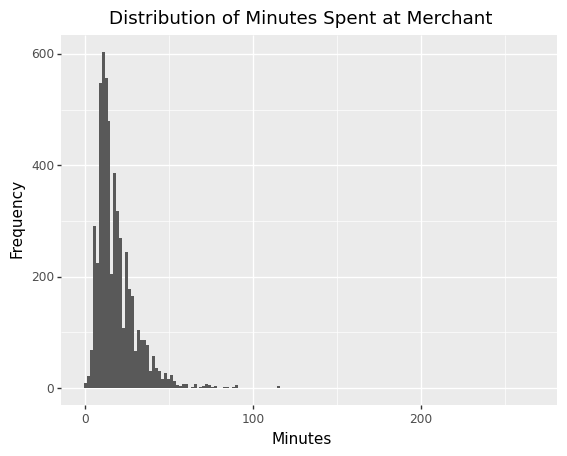

```python
(
ggplot(jump23) +
    aes('time_at_merchant') +
    geom_histogram(na_rm = True) +
    labs(title = 'Distribution of Minutes Spent at Merchant', x = 'Minutes', y = 'Frequency')
)
```

```python
jump23['time_at_merchant'].describe()
```

```
count    5433.000000
mean       18.355052
std        12.450314
min         0.000000
25%        10.000000
50%        15.000000
75%        23.000000
max       267.000000
Name: time_at_merchant, dtype: float64
```

```python
jump23[jump23['time_at_merchant'] > 105]
```

|  | delivery_id | customer_id | jumpman_id | vehicle_type | pickup_place | place_category | item_name | item_quantity | item_category_name | ordering_duration | pickup_lat | pickup_lon | dropoff_lat | dropoff_lon | delivery_start_time | merchant_arrival_time | merchant_departure_time | customer_arrival_time | delivery_duration | time_at_merchant |
| --- | --- | --- | --- | --- | --- | --- | --- | --- | --- | --- | --- | --- | --- | --- | --- | --- | --- | --- | --- | --- |
| 335 | 1347642 | 100889 | 15291 | car | Whole Foods Market | Grocery Store | Syrah | 1.0 | Wine | NaN | 40.768062 | -73.981848 | 40.764704 | -73.976055 | 2014-10-12 16:39:25.479283 | 2014-10-12 17:15:13.555148 | 2014-10-12 19:11:03.150759 | 2014-10-12 19:15:35.502186 | 02:36:10.022903 | 115.0 |
| 1606 | 1381673 | 377260 | 166715 | bicycle | Blue Ribbon Fried Chicken | American | The Blue Ribbon | 1.0 | Sandwiches | NaN | 40.724340 | -73.990960 | 40.723676 | -74.010723 | 2014-10-17 17:36:36.655417 | 2014-10-17 17:39:57.071973 | 2014-10-17 22:07:54.314590 | 2014-10-17 23:16:55.184017 | 05:40:18.528600 | 267.0 |
| 2873 | 1347642 | 100889 | 15291 | car | Whole Foods Market | Grocery Store | Org Local Eggs Pasture Raised | 1.0 | Eggs | NaN | 40.768062 | -73.981848 | 40.764704 | -73.976055 | 2014-10-12 16:39:25.479283 | 2014-10-12 17:15:13.555148 | 2014-10-12 19:11:03.150759 | 2014-10-12 19:15:35.502186 | 02:36:10.022903 | 115.0 |
| 3356 | 1347642 | 100889 | 15291 | car | Whole Foods Market | Grocery Store | Cottage Cheese Small Curd | 2.0 | Cottage Cheese | NaN | 40.768062 | -73.981848 | 40.764704 | -73.976055 | 2014-10-12 16:39:25.479283 | 2014-10-12 17:15:13.555148 | 2014-10-12 19:11:03.150759 | 2014-10-12 19:15:35.502186 | 02:36:10.022903 | 115.0 |
| 5969 | 1347642 | 100889 | 15291 | car | Whole Foods Market | Grocery Store | Salad Clam Ogirl Baby Spinach 5oz Og | 1.0 | Packaged Salad & Fruit | NaN | 40.768062 | -73.981848 | 40.764704 | -73.976055 | 2014-10-12 16:39:25.479283 | 2014-10-12 17:15:13.555148 | 2014-10-12 19:11:03.150759 | 2014-10-12 19:15:35.502186 | 02:36:10.022903 | 115.0 |

**All but one of the deliveries that spent over 1 hour and 45 minutes at the merchant were car-delivered orders. This raises a question: how are we recording merchant arrival time? If a car arrives outside of the merchant but spends 45 minutes trying to park, when does the merchant arrival time begin?**

### Item Quantity per Order: What items have the highest average order quantity per order?

```python
def show_all(x):
    pd.set_option('display.max_rows', len(x))
    display(x)
    pd.reset_option('display.max_rows')

agg_item_quant = jump23.groupby(['item_name'])['item_quantity'].agg(['mean','count']).sort_values(by = 'mean', ascending = False)
show_all(agg_item_quant[agg_item_quant['count'] > 1])
```

| item_name | mean | count |
| --- | --- | --- |
| Naan | 6.333333 | 3 |
| Wing | 5.500000 | 2 |
| Ginger Fireball | 4.666667 | 3 |
| Pescado A Las Brasas | 4.500000 | 2 |
| New Yorker | 4.500000 | 4 |
| District Cobb | 3.500000 | 2 |
| King Salmon | 3.333333 | 3 |
| Toro | 3.333333 | 3 |
| Almond Butter Bliss | 3.250000 | 4 |
| Roti | 3.000000 | 2 |
| Anne Pichon Sauvage | 3.000000 | 2 |
| Vanilla Cake | 3.000000 | 2 |
| Full Wing | 3.000000 | 3 |
| Drumstick | 2.777778 | 9 |
| Veggie Sandwich Combo | 2.666667 | 3 |
| Tender | 2.615385 | 13 |
| Thigh | 2.571429 | 7 |
| Momoya Spicy Tuna | 2.500000 | 2 |
| Bonchon Soy-Garlic Wings | 2.500000 | 2 |
| Red Velvet Cupcake | 2.500000 | 2 |
| Red Hook Lobster Pound Lobster BLT | 2.500000 | 2 |
| Half Chicken | 2.500000 | 2 |
| Blue Ribbon Fried Chicken Sandwich + Fries | 2.500000 | 2 |
| Marinara | 2.500000 | 2 |
| Chocolate Chip Walnut | 2.500000 | 8 |
| Chicken Tikka Roll | 2.500000 | 2 |
| Yellowtail Sashimi with Jalapeno | 2.400000 | 5 |
| Sake | 2.357143 | 14 |
| Caramel a la fleur de sol | 2.333333 | 3 |
| The Melt Shop Fried Chicken Sandwich | 2.333333 | 3 |

[output cut: 745 more lines]

**For items that were ordered more than once in the dataset, Naan has the highest average item quantity per order. No major anomalies in order volume outside of the missing values.**

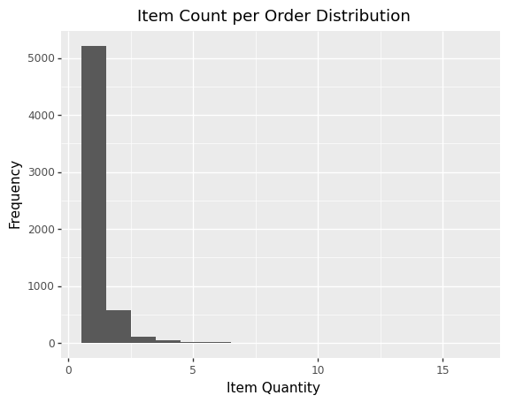

```python
(
ggplot(jump23) +
    aes('item_quantity') +
    geom_histogram(na_rm = True, binwidth = 1) +
    labs(title = 'Item Count per Order Distribution', x = 'Item Quantity', y = 'Frequency')

)
```

```python
average_orders = "Average item quantity per order is {}".format(round(jump23['item_quantity'].describe()[1],2))
print(average_orders)
```

```
Average item quantity per order is 1.2
```